# Visual Analysis of Prosper Loan Data

## by Stetson Done

## Investigation Overview

> Through this investigation, we will see how borrower credit scores affect both the borrower and the lender. We'll answer the following questions through data analysis and visualization:

> 1) How does a borrower's credit score affect their annual interest rate?  
> 2) How does the borrower's credit score affect the loan risk for the lender?  
> 3) How do the borrower credit score distributions vary between current loans and defaulted loans?

## Dataset Overview

> This dataset is comprised of loan and borrower data from Prosper, a peer to peer lending company.

## How does a borrower's credit score affect their annual interest rate?

> Using the pearsonr calculation and a seaborn regression plot, I found there is a moderate negative correlation between the borrower's loan interest rate and their credit score. As the borrower's credit score increased, their annual interest rate decreases.

> The correlation coefficient was -0.4 with a p-value of 0, which indicates the results are statistically significant.

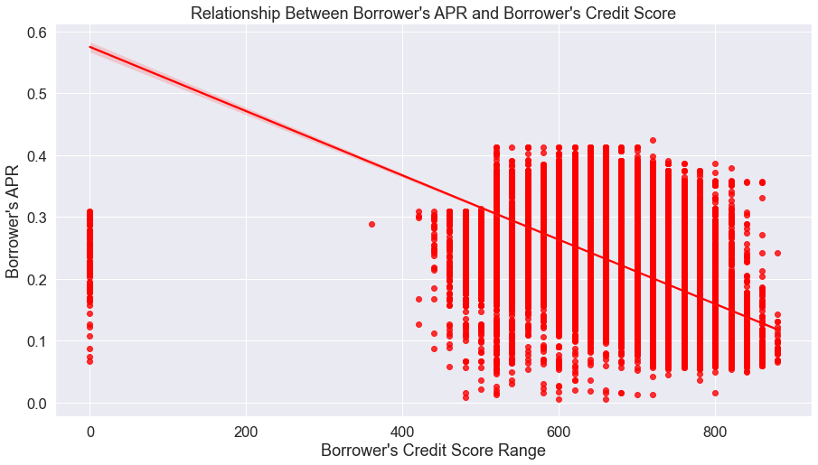

## How does a borrower's credit score affect the estimated loan risk for the lender?

> The correlation coefficient was -0.5 with a p-value of 0, which indicates the results are statistically significant.

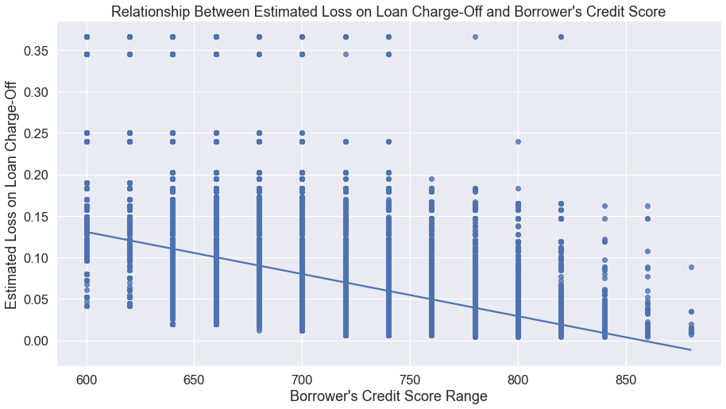

## How do the borrower credit score distributions vary between current loans and defaulted loans?

> The borrower credit score distribution was higher on current loans and lower on defaulted loans. In fact, the mean borrower credit score on current loans ranged from 698 - 717, while the mean borrower credit score on defaulted loans ranged from 620 - 639.

> The median borrower credit scores for current loans ranged from 700 - 719 and the median borrower scores for defaulted loans ranged from 640 to 659.

[figure not shown]

[figure not shown]